# 5. Matplotlib

## 5. Matplotlib

```python
# Подключение необходимых библиотек
import matplotlib.pyplot as plt
import numpy as np
```

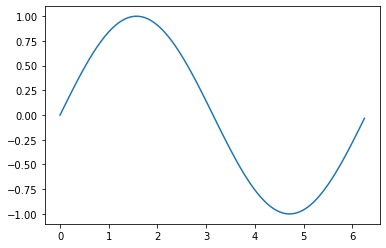

```python
# Выведем в качестве примера синусоиду. Изображение, скорее всего, будет размытым, но дальше мы это поправим
x = np.arange(0, np.pi*2, 0.05)
y = np.sin(x)
plt.plot(x,y)
```

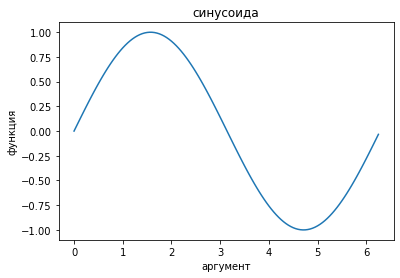

```python
# Соответсвующие поля класса позволяют управлять подписями к графику и осям
x = np.arange(0, np.pi*2, 0.05)
y = np.sin(x)
plt.xlabel("аргумент") # Подпись к оси x
plt.ylabel("функция") # Подпись к оси y
plt.title('синусоида') # Подпись полотна графика
# Чтобы строка вида [<matplotlib.lines.Line2D at 0x7f1421b248b0>] не выпрыгивала, в конце ставим точку с запятой
plt.plot(x,y);
```

Чтобы не было глюков системы, следует создавать фигуру в той же ячейке, что и оси. Пустое окно в теории можно отрисовать, но в Jupyter по умолчанию matplotlib запущен в non-GUI режиме, чтобы окна с нулевым содержимым не отрисовывались. С точки зрения объектного подхода, фигура не является графиком, а является по сути резервом памяти для дальнейшего построения в заданной области памяти графиков. Для построения графиков на фигуре нужно добавить собственно объект — график. На фигуре с именем fig создать график с именем ax. У графика одна ось, поскольку функции передан только один список. В списке четыре элемента: первые два - это координаты левого нижнего угла графика, далее идет ширина и высота графика. Единицы измерения указываются относительно размеров фигуры.

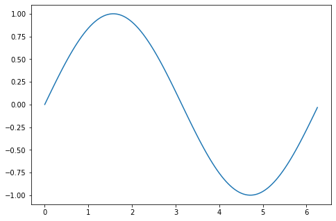

```python
# Объектно - ориентированный подход при создании графиков
x = np.arange(0, np.pi*2, 0.05)
y = np.sin(x)
fig = plt.figure() # первым шагом создадим пустое окно - фигуру
ax = fig.add_axes([0,0,1,1])
ax.plot(x,y);
```

```
Figure(432x288)
```

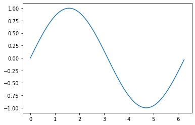

```python
# Если использовать команду print, можно узнать, сколько точек на экране занимает график
fig, ax = plt.subplots()
x = np.arange(0, np.pi*2, 0.05)
y = np.sin(x)
ax.plot(x,y)
print(fig)
```

Размер рисунка (figsize) определяет размер фигуры в дюймах, т.е. размеры пространства, в котором оси (и другие элементы) находятся внутри фигуры. Размер фигуры по умолчанию составляет (6, 4) дюйма. Более крупный размер фигуры позволит показывать более длинные тексты, больше осей или больше меток.

Количество точек на дюйм (dpi) определяет, сколько пикселей содержит фигура. Значение dpi по умолчанию в matplotlib равно 72. Рисунок figsize=(w,h) будет иметьразрешение w*dpi* h*dpi пикселей, например при figsize=(6.4,4.8) и 100 dpi мы получим расрешение 640*480 пикселей

Таким образом, чтобы получить фигуру с размером пикселей, например. (1200,600) вы можете выбрать несколько комбинаций размера фигуры и dpi, например:

figsize=(15,7.5), dpi= 80

figsize=(12,6) , dpi=100

figsize=( 8,4) , dpi=150

figsize=( 6,3) , dpi=200

В чем разница между указанными выше вариантами? Большинство элементов, таких как линии, маркеры, тексты, имеют размер, указанный в точках. Например линия с толщиной в одну точку будет эквивалентна линии толщиной 1/72 дюйма. Текст с размером шрифта 12 пунктов будет 12./72. дюймовым. Конечно, если изменить размер фигуры в дюймах, точки не изменятся, поэтому большая фигура в дюймах по-прежнему будет иметь одинаковый размер элементов. Изменение размера фигуры — это тоже самое, как если бы в реальной жизни начали рисовать той же ручкой на бумаге большего размера: толщина линии от размера бумаги не зависит.

С другой стороны, изменение dpi масштабирует эти элементы. При 72 dpi линия толщиной в одну точку составляет один пиксель. При 144 dpi эта линия имеет толщину 2 пикселя. Таким образом, большие dpi будут действовать как увеличительное стекло.

```python
# Размеры графиков в точках
fig = plt.figure() # По умолчанию
print('По умолчанию',fig)

fig = plt.figure(figsize = [6,4],dpi = 72) # По умолчанию Jupyter выбирает размер и dpi именно такими
print('Опять же по умолчанию',fig)

fig = plt.figure(figsize = [6,4],dpi = 72*2)
print('Удвоенное dpi',fig)

fig = plt.figure(figsize = [6*2,4*2],dpi = 72*2)
print('Удвоенное dpi и удвоенный размер',fig)
```

```
По умолчанию Figure(432x288)
Опять же по умолчанию Figure(432x288)
Удвоенное dpi Figure(864x576)
Удвоенное dpi и удвоенный размер Figure(1728x1152)
```

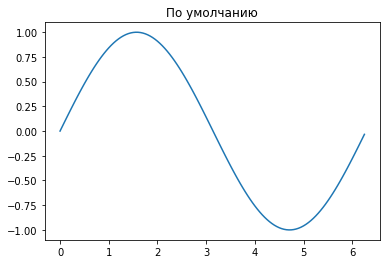

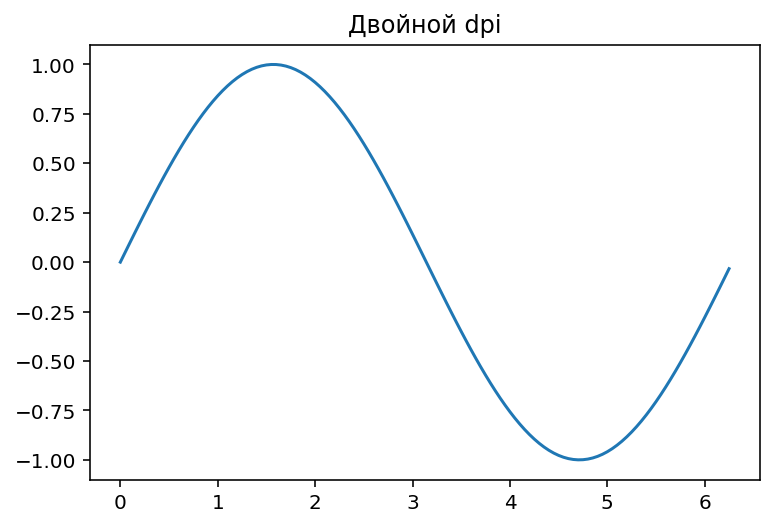

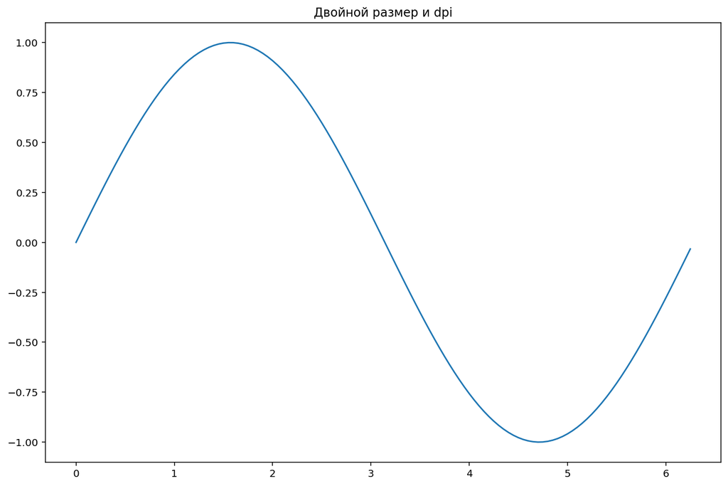

```python
# Обратите внимание, что при тех же размерах, но удвоенном dpi, линии и шрифты станут удвоенной толщины
x = np.arange(0, np.pi*2, 0.05)
y = np.sin(x)

fig, ax = plt.subplots()
ax.plot(x,y)
plt.title('По умолчанию')
fig, ax = plt.subplots(figsize = [6,4],dpi = 72*2)
ax.plot(x,y)
plt.title('Двойной dpi')
fig, ax = plt.subplots(figsize = [6*2,4*2],dpi = 72*2)
ax.plot(x,y)
plt.title('Двойной размер и dpi');
```

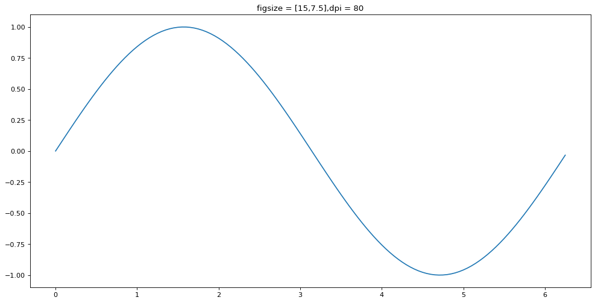

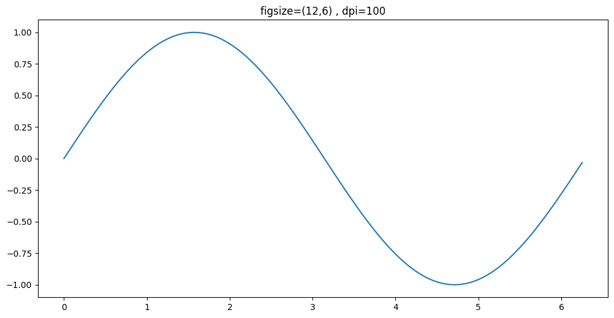

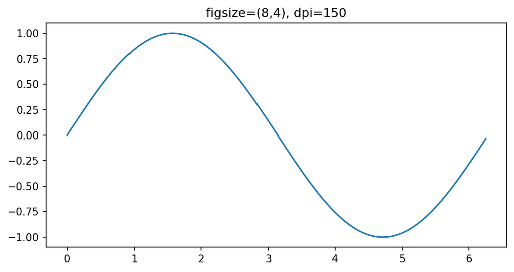

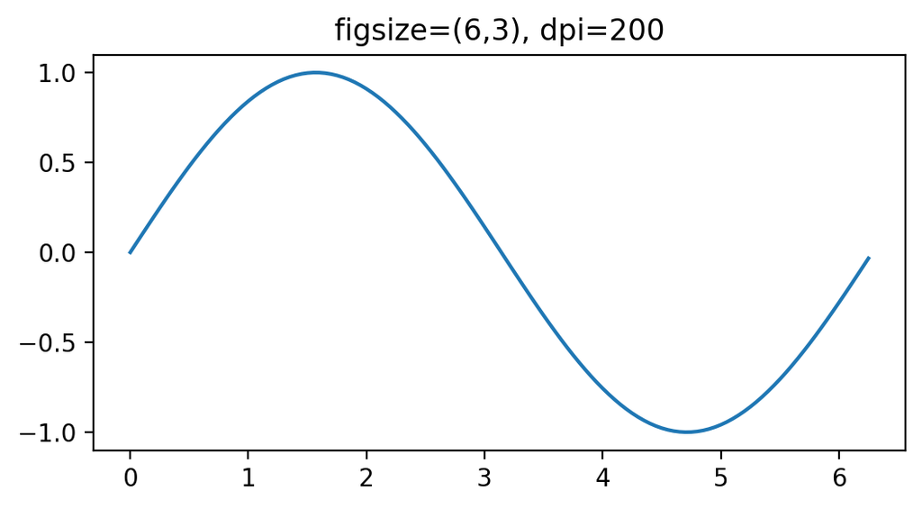

```python
# Разрешение 1200*600
x = np.arange(0, np.pi*2, 0.05)
y = np.sin(x)

fig, ax = plt.subplots(figsize = [15,7.5],dpi = 80)
ax.plot(x,y)
plt.title('figsize = [15,7.5],dpi = 80')

fig, ax = plt.subplots(figsize=(12,6), dpi=100)
ax.plot(x,y)
plt.title('figsize=(12,6) , dpi=100')

fig, ax = plt.subplots(figsize=(8,4), dpi=150)
ax.plot(x,y)
plt.title('figsize=(8,4), dpi=150')

fig, ax = plt.subplots(figsize=(6,3), dpi=200)
ax.plot(x,y)
plt.title('figsize=(6,3), dpi=200');
```

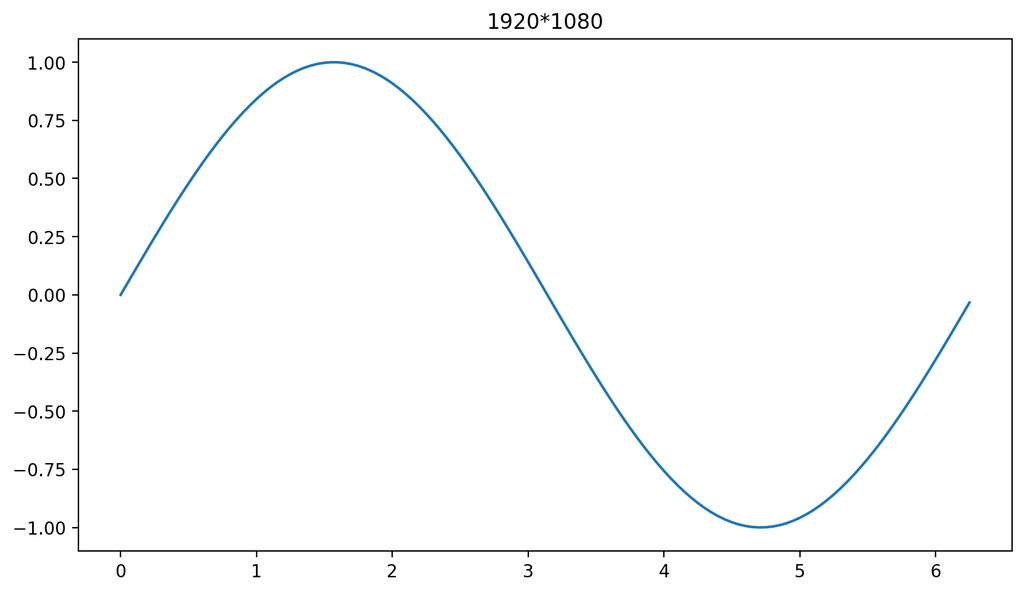

```python
# FullHD при 200 dpi
x = np.arange(0, np.pi*2, 0.05)
y = np.sin(x)

fig, ax = plt.subplots(figsize=(9.6,5.4), dpi=200)
ax.plot(x,y)
plt.title('1920*1080');
```

Существует возможность установки значений по умолчанию. Выберите те значения, которые лучше всего подходят для вашего монитора.

```python
# Размер графиков по умолчанию, а также чёткость (качество) картинки можно задавать параметрми по умолчанию
# Параметры по умолчанию сбрасываются каждый раз при перезапуске ядра Jupyter
plt.rcParams['figure.dpi'] = 200
plt.rcParams["figure.figsize"] = (9.6,5.4)
plt.rcParams["axes.grid"] = True # всегда включать сетку на любых новых графиках
```

```python
# Центрировать графики простым способом не получится. Для этого нужно модифицировать HTML - ядро программы
from IPython.core.display import HTML
HTML("""
<style>
.output_png {
    display: table-cell;
    text-align: center;
    vertical-align: middle;
}
</style>
""")
```

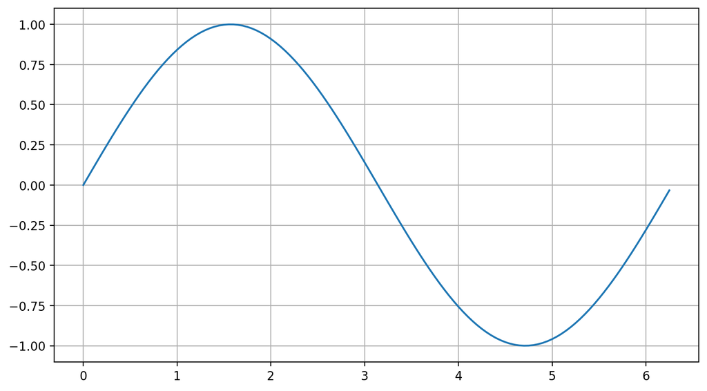

```python
x = np.arange(0, np.pi*2, 0.05)
y = np.sin(x)
plt.plot(x,y);
```

```python
# Полный список установок по умолчанию можно посмотреть в документации или в специальном файле
import matplotlib as mtpllib # для этого придётся обратиться к корневому модулю библиотеки
mtpllib.matplotlib_fname()# команда выведет полный путь к файлу
```

```
'/usr/local/lib/python3.8/dist-packages/matplotlib/mpl-data/matplotlibrc'
```

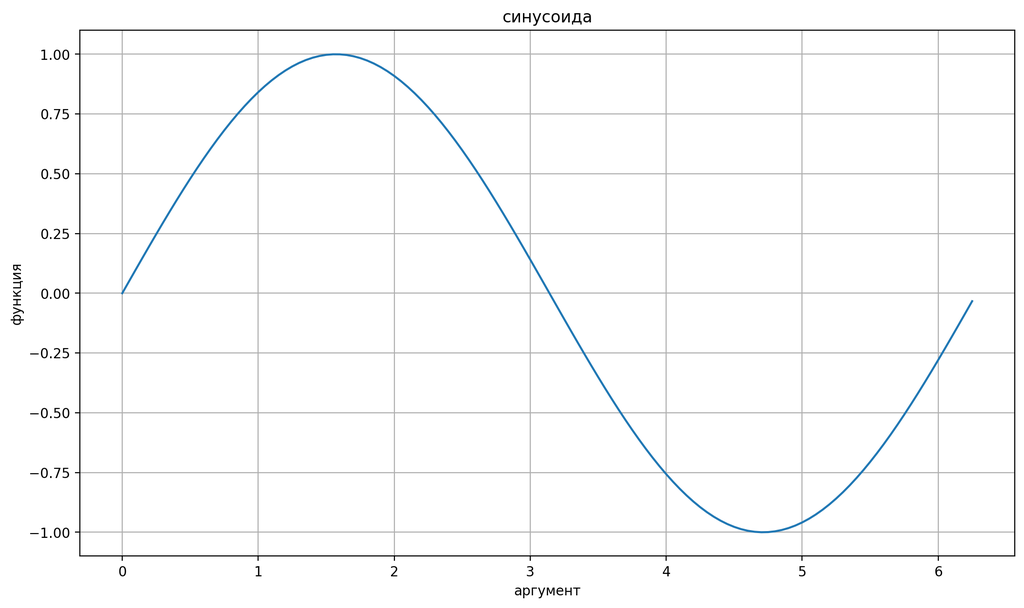

```python
# В объектном подходе для установки подписей, нужно дописывать везде set_
x = np.arange(0, np.pi*2, 0.05)
y = np.sin(x)

fig = plt.figure()
ax = fig.add_axes([0,0,1,1])
ax.plot(x,y)
ax.set_xlabel("аргумент") # Подпись к оси x
ax.set_ylabel("функция") # Подпись к оси y
ax.set_title('синусоида'); # Подпись полотна графика
```

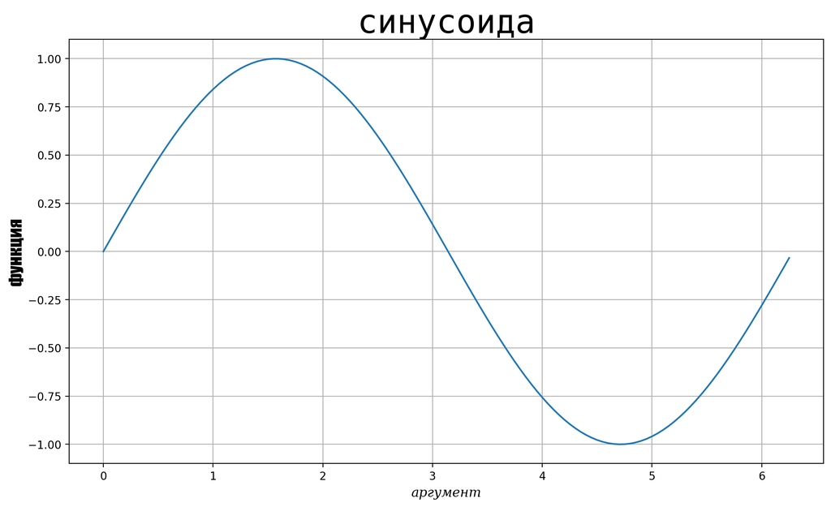

```python
# Параметры подписей можно менять
x = np.arange(0, np.pi*2, 0.05)
y = np.sin(x)

fig = plt.figure()
ax = fig.add_axes([0,0,1,1])
ax.plot(x,y)
ax.set_xlabel("аргумент",fontfamily = 'serif',fontstyle = 'italic',fontsize = 12)
ax.set_ylabel("функция",fontfamily = 'fantasy',fontstyle = 'oblique',fontsize = 16)
ax.set_title('синусоида',fontfamily = 'monospace',fontstyle = 'normal',fontsize = 30);
```

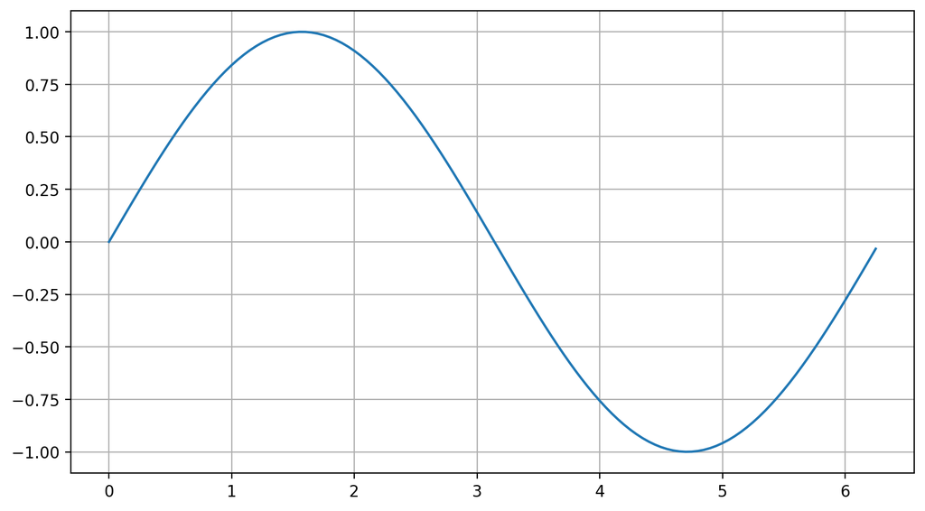

```python
# Поскольку в большинстве случаев нам нужен один график с единственной осью, можно использовать иной синтаксис
fig, ax = plt.subplots() # subplots сразу создает две переменные и по умолчанию единственный график
x = np.arange(0, np.pi*2, 0.05)
y = np.sin(x)
ax.plot(x,y);
```

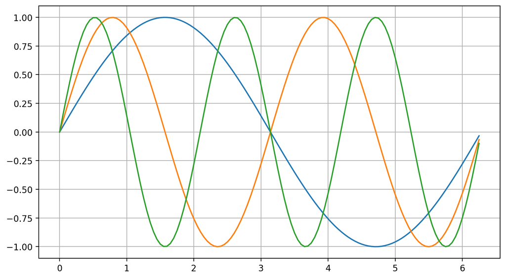

```python
# По умолчанию добавление новых линий на график не затирает предыдущие
x = np.arange(0, np.pi*2, 0.05)
y1 = np.sin(x)
y2 = np.sin(2*x)
y3 = np.sin(3*x)
fig, ax = plt.subplots()
ax.plot(x,y1,x,y2,x,y3); # Новые графики добавляются подряд парами x и y через запятую
```

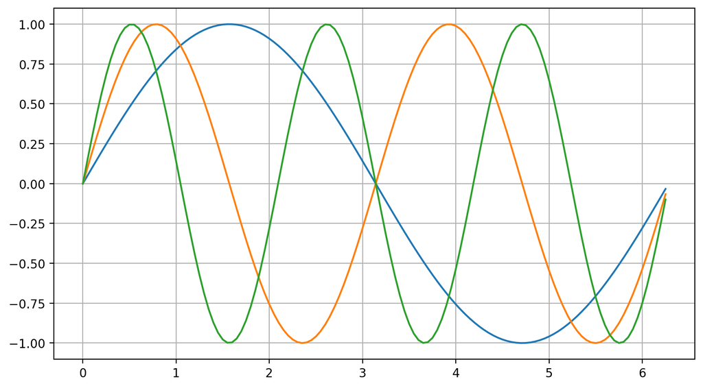

```python
# Можно добавлять графики последовательными командами
x = np.arange(0, np.pi*2, 0.05)
y1 = np.sin(x)
y2 = np.sin(2*x)
y3 = np.sin(3*x)
fig, ax = plt.subplots()
ax.plot(x,y1)
ax.plot(x,y2)
ax.plot(x,y3);
```

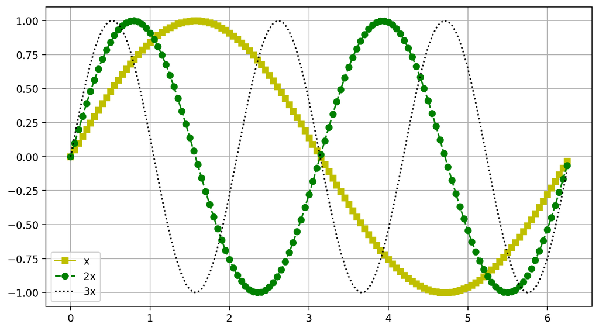

```python
# По умолчанию цвет и тип линии для графика выбирается автоматически согласно текущему стилю
# Цвет, тип линии, маркер можно задавать вручную. Также можно добавить легенду
x = np.arange(0, np.pi*2, 0.05)
y1 = np.sin(x)
y2 = np.sin(2*x)
y3 = np.sin(3*x)
fig, ax = plt.subplots()
ax.plot(x,y1,'ys-') # жёлтая линия (y), с квадратным маркером (s), сплошного типа (-)
ax.plot(x,y2,'go--') # зелёная линия (g), с круглым маркером (o), пунктирного типа (--)
ax.plot(x,y3,'k:')  # черная линия (g), без маркера, с линией, состоящей из точек (:)
# Добавим легенду: labels - текстовые строки для легенды, привязываются к графикам в порядке их отрисовки
# loc - местопоожение легенды
ax.legend(labels = ('x', '2x','3x'), loc = 'lower left');
```

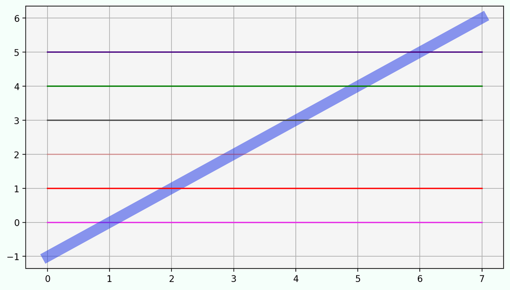

```python
# Можно индивидуально задавать цвет линии
x = np.zeros(8)

fig, ax = plt.subplots()

# RGB:
ax.plot(x, color = (0.9, 0.2, 0.9))

# RGBA (с прозрачностью 0.5):
ax.plot(np.arange(-1, 7),
        color = (0.1, 0.2, 0.9, 0.5),
        linewidth = 12)

# hex RGB:
ax.plot(x + 1, color = '#ff0000') # Красный

# hex RGBA:
ax.plot(x + 2, color = '#ff00003a') # Красный полупрозрачный

# уровень серого в интервале [0, 1]:
ax.plot(x + 3, color = '0.3')

# ключ цвета из {'b', 'g', 'r', 'c', 'm', 'y', 'k', 'w'}:
ax.plot(x + 4, color = 'g')

# название цвета из X11/CSS4:
ax.plot(x + 5, color = 'indigo')

fig.set_facecolor('mintcream') # Можно разукрасить подложку графика (использован цвет из X11/CSS4)
ax.set_facecolor('whitesmoke') # Можно разукрасить фон графика (использован цвет из X11/CSS4)
```

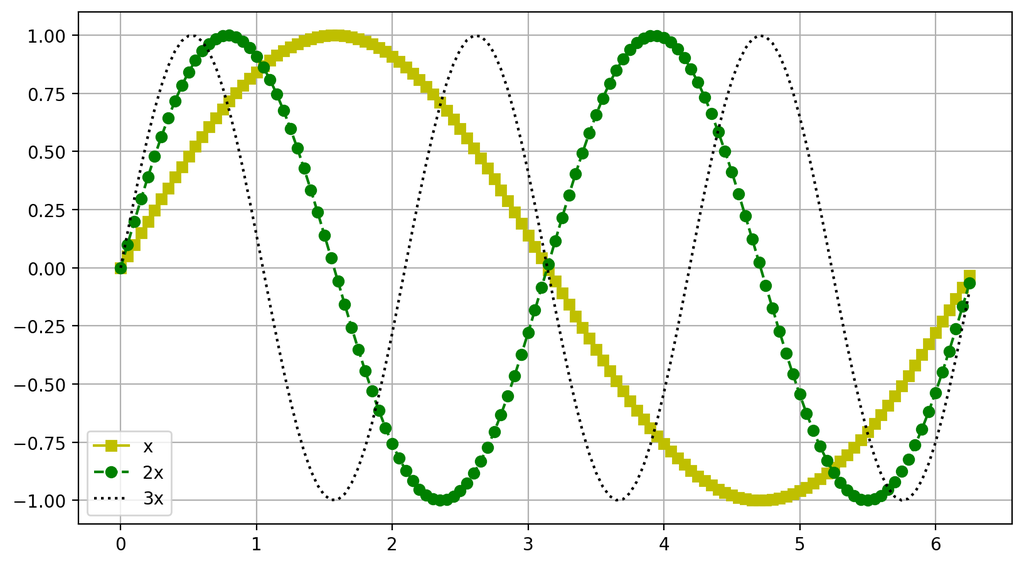

```python
# Текстовые метки можно привязывать сразу к каждому графику, добавив в метод plot аргумент label
x = np.arange(0, np.pi*2, 0.05)
y1 = np.sin(x)
y2 = np.sin(2*x)
y3 = np.sin(3*x)
fig, ax = plt.subplots()
ax.plot(x,y1,'ys-',label = 'x')
ax.plot(x,y2,'go--',label = '2x')
ax.plot(x,y3,'k:',label = '3x')
ax.legend(loc = 'lower left');
```